# FA Homework - 4 Report

Author

Venkat Satya Uday Dhanush Karri

Published

September 19, 2025

# Setup and Imports

```python
import pandas as pd
import numpy as np
import matplotlib.pyplot as plt

# --- Load data ---
ccm_path = r"C:\FA25\CCM_main.parquet"
sp500_path = r"C:\FA25\sp500list.parquet"

ccm = pd.read_parquet(ccm_path)
sp500 = pd.read_parquet(sp500_path)

print("sp500 rows:", sp500.shape)
print("ccm rows:", ccm.shape)
```

```
sp500 rows: (2064, 3)
ccm rows: (3163964, 49)
```

# Q1 (a) What is the theory of popularity?

The theory of popularity says price and expected returns depend not only on fundamentals and risk but also on how popular an asset is. Popularity here means ease of ownership (liquidity), index inclusion, visibility, and investor flows — assets that are widely held, easy to trade, and hyped tend to trade at higher prices and therefore have lower expected returns than less-popular, harder-to-hold assets. I agree in large part: popularity helps explain persistent return differences within an asset class (e.g., among stocks) because it affects demand, liquidity premia, and who ends up owning the asset.

# Q1 (b) What does the quoted sentence mean?

Answer: It means cross-asset return differences (stocks vs bonds) are largely explained by risk; but within an asset class (e.g., within equities) returns vary for reasons other than risk — such as popularity, liquidity, index inclusion, and investor behavior.

# Q1 (c) Which popularity measures matter now?

Answer: Important measures today include ETF/ETF flows, AUM, turnover/liquidity, index inclusion (S&P/FTSE), retail attention (Google trends/social), and short interest; I would prioritize ETF ownership and flows plus liquidity as the most impactful.

# —————————————————————————-

# Q2 (a) What is GICS?

GICS (Global Industry Classification Standard) is a hierarchical industry taxonomy created by MSCI and S&P. It splits publicly traded firms into 11 sectors, which break into industry groups, industries, and sub-industries. The classification standard gives a consistent way to compare companies across time and indexes (e.g., IT vs Financials), and it’s widely used for sector weights, performance attribution, and index construction.

```
Expanded S&P500 monthly rows: 442552
Total rows after merge: 442552
IT rows: 31234
```

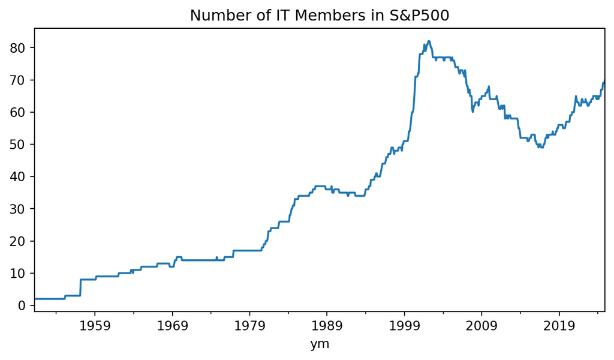

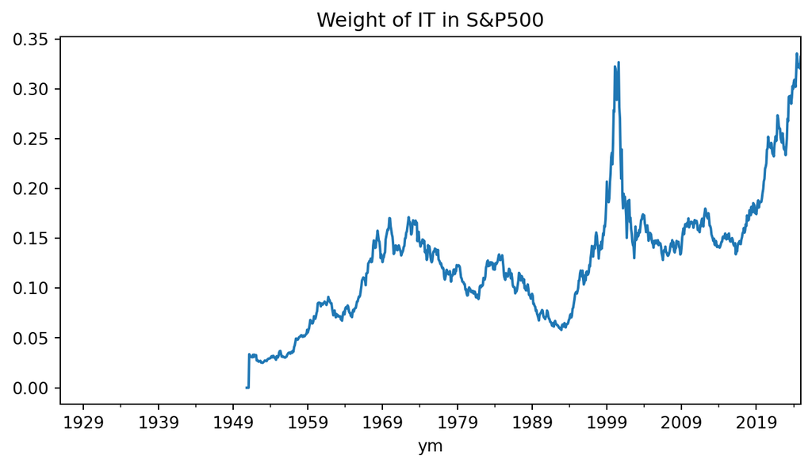

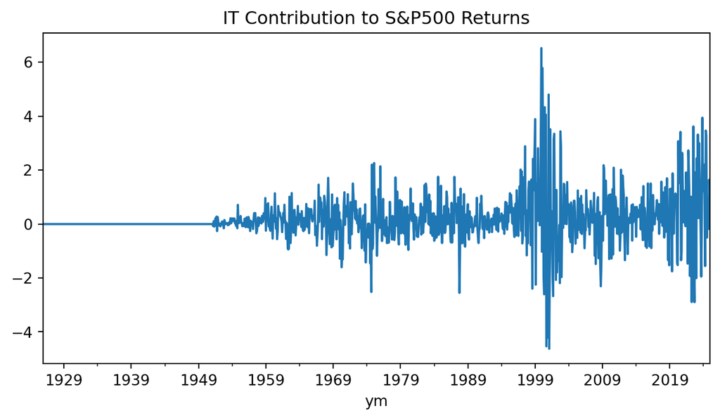

```python
# Q2. IT concentration in S&P500

# --- expand sp500 membership monthly ---
sp500_expanded = []
for _, row in sp500.iterrows():
    start = pd.to_datetime(row['startdt'])
    end = pd.to_datetime(row['enddt'])
    months = pd.period_range(start.to_period('M'), end.to_period('M'), freq='M')
    for m in months:
        sp500_expanded.append({'permno': row['permno'], 'ym': m.to_timestamp()})
sp500m = pd.DataFrame(sp500_expanded)
print("Expanded S&P500 monthly rows:", len(sp500m))

# --- make CCM monthly ---
ccm['ym'] = ccm['date'].dt.to_period('M').dt.to_timestamp()

# --- merge ---
df2 = sp500m.merge(ccm, on=['permno','ym'], how='left')

# --- marketcap ---
df2['marketcap'] = df2['prc'].abs() * df2['shrout']

# --- IT flag ---
df2['Industry'] = df2['Industry'].astype(str).str.strip()
df2['is_IT'] = (df2['Industry'] == 'IT') | (df2['gsector'].fillna(0).round().astype(int) == 45)

print("Total rows after merge:", len(df2))
print("IT rows:", df2['is_IT'].sum())

# (b) Number of IT members
it_counts = df2[df2['is_IT']].groupby('ym').permno.nunique()
it_counts.plot(title='Number of IT Members in S&P500', figsize=(8,4))
plt.show()

# (c) IT weight
weights = df2.groupby(['ym','is_IT'])['marketcap'].sum().unstack(fill_value=0)
if True not in weights.columns:
    weights[True] = 0
weights['it_weight'] = weights[True] / weights.sum(axis=1)
weights['it_weight'].plot(title='Weight of IT in S&P500', figsize=(8,4))
plt.show()

# (d) IT contribution to returns
df2['wgt'] = df2['marketcap'] / df2.groupby('ym')['marketcap'].transform('sum')
df2['contrib'] = df2['wgt'] * df2['ret']
it_contrib = df2.groupby(['ym','is_IT'])['contrib'].sum().unstack(fill_value=0)
if True not in it_contrib.columns:
    it_contrib[True] = 0
it_contrib[True].plot(title='IT Contribution to S&P500 Returns', figsize=(8,4))
plt.show()
```

# ——————————————————————————

```
           mean       std  ann_mean
VW     0.015446  0.042946  0.201945
SP500  0.007373  0.041992  0.092152
FW     0.010244  0.045497  0.130099
```

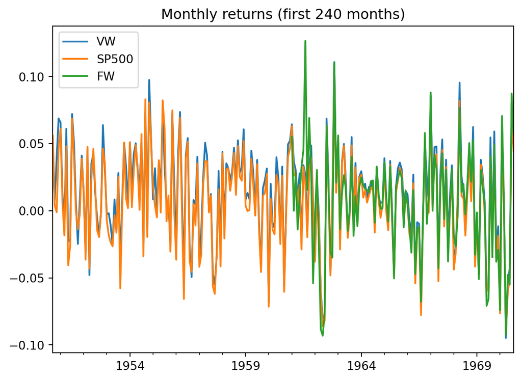

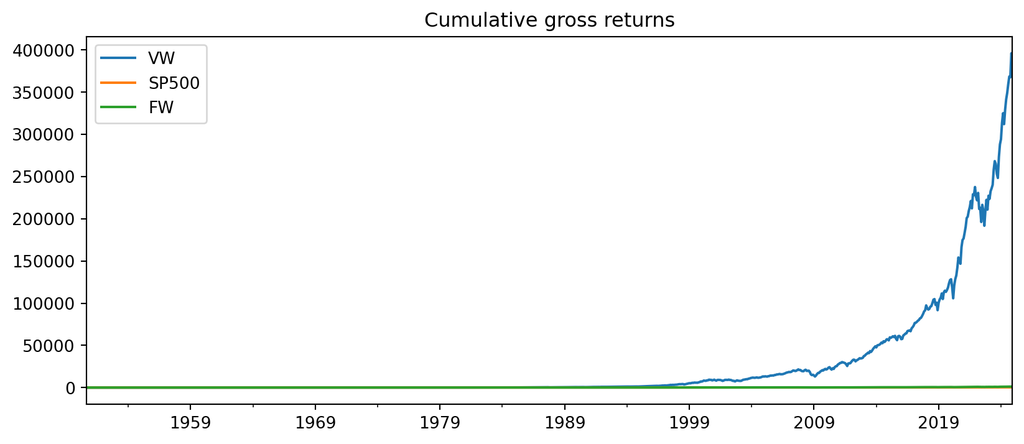

```python
# 3. Top-1000 portfolios
ccm2 = ccm.copy()
ccm2['ym'] = ccm2['date'].dt.to_period('M').dt.to_timestamp()

# Marketcap
if 'marketcap' not in ccm2.columns:
    ccm2['marketcap'] = ccm2['prc'].abs() * ccm2['shrout']

# Returns
ccm2['ret'] = pd.to_numeric(ccm2['ret'], errors='coerce')
if ccm2['ret'].abs().max() > 1.5:
    ccm2['ret'] = ccm2['ret'] / 100
if 'sprtrn' in ccm2.columns and ccm2['sprtrn'].abs().max() > 1.5:
    ccm2['sprtrn'] = ccm2['sprtrn'] / 100

# Top 1000
ccm2['rank'] = ccm2.groupby('ym')['marketcap'].rank(method='first', ascending=False)
ccm_top = ccm2[ccm2['rank'] <= 1000].copy()

# VW
vw = ccm_top.groupby('ym').apply(lambda g: (g['marketcap']/g['marketcap'].sum()*g['ret']).sum()).rename('VW')

# SP500
if 'sprtrn' in ccm_top.columns:
    sp500_index = ccm_top.groupby('ym')['sprtrn'].mean().rename('SP500')
else:
    sp500_index = pd.Series(index=vw.index, data=np.nan, name='SP500')

# FW (using ceq)
fw_returns = []
ccm_top['year'] = ccm_top['ym'].dt.year
for year, grp in ccm_top.groupby('year'):
    jan = grp[grp['ym'] == pd.Timestamp(year=year, month=1, day=1)]
    if jan.empty: continue
    jan_fund = jan.set_index('permno')['ceq'].dropna()
    if jan_fund.sum() == 0: continue
    jan_weights = jan_fund / jan_fund.sum()
    for m in sorted(grp['ym'].unique()):
        mdf = grp[grp['ym'] == m].set_index('permno')
        aligned = mdf.join(jan_weights.rename('fw_w'))
        aligned['fw_w'] = aligned['fw_w'].fillna(0)
        fw_ret = (aligned['fw_w'] * aligned['ret']).sum()
        fw_returns.append({'date': m, 'FW': fw_ret})
fw = pd.DataFrame(fw_returns).set_index('date').sort_index()

# Combine
ports = pd.concat([vw, sp500_index, fw['FW']], axis=1).dropna(how='all')

# Summary
summary = ports.agg(['mean','std']).transpose()
summary['ann_mean'] = (1 + summary['mean'])**12 - 1
print(summary)

# Plot monthly and cumulative returns
plt.figure(figsize=(10,4))
ports[['VW','SP500','FW']].iloc[:240].plot(title='Monthly returns (first 240 months)')
plt.show()

cum = (1 + ports.fillna(0)).cumprod() - 1
cum[['VW','SP500','FW']].plot(title='Cumulative gross returns', figsize=(10,4))
plt.show()
```

```
Beta mean, std: 1.107930543177245 0.6295032700197098
Negative betas: 1281
Alpha mean, std: 0.006080693545491564 0.012862141387277615
Positive alphas: 98434 Negative alphas: 36435
```

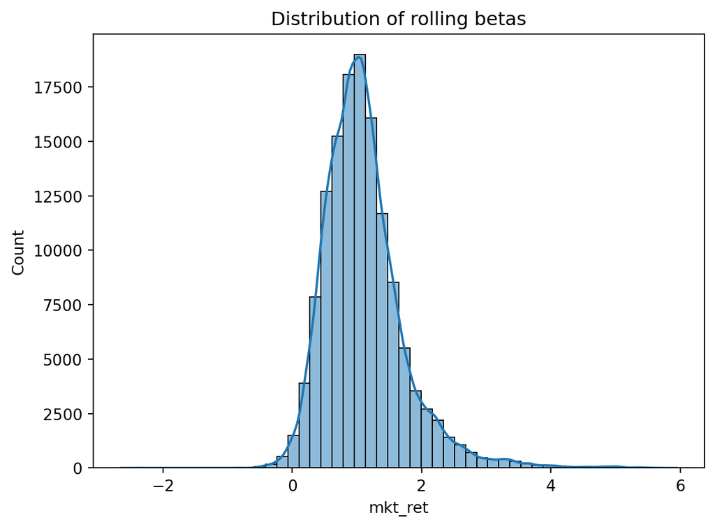

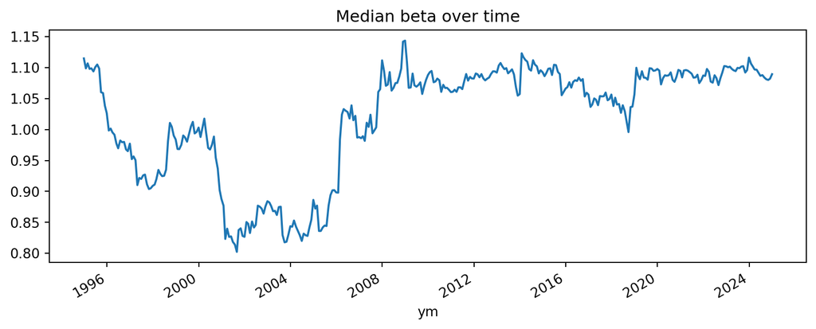

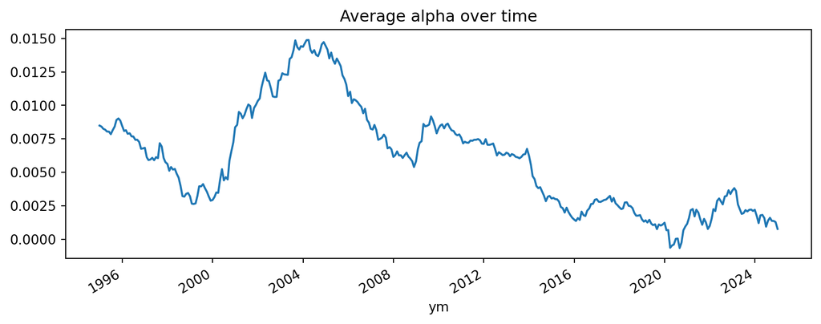

```python
# Q4. CAPM α and β
import statsmodels.api as sm
from statsmodels.regression.rolling import RollingOLS
import seaborn as sns   # <--- FIX: import seaborn here
import matplotlib.pyplot as plt

ccm_cap = ccm2.copy()
ccm_cap['marketcap'] = pd.to_numeric(ccm_cap['marketcap'], errors='coerce')
ccm_cap = ccm_cap[ccm_cap['date'] >= '1990-01-01']

# Top-200 by lagged marketcap each Jan
years = sorted(ccm_cap['date'].dt.year.unique())
permnos_top = []
for y in years:
    prev_dec = pd.Timestamp(year=y-1, month=12, day=1)
    snap = ccm_cap[ccm_cap['date'].dt.to_period('M').dt.to_timestamp() == prev_dec]
    if snap.empty: continue
    top200 = snap.sort_values('marketcap', ascending=False).head(200)['permno'].unique()
    permnos_top.extend(list(top200))
permnos_top = list(set(permnos_top))
ccm_cap2 = ccm_cap[ccm_cap['permno'].isin(permnos_top)].copy()

# Market return
ccm_cap2['mkt_ret'] = pd.to_numeric(ccm_cap2['sprtrn'], errors='coerce')

# Rolling regressions
results = []
for pid, g in ccm_cap2.groupby('permno'):
    g = g.sort_values('date').set_index('date')
    if len(g) < 60: continue
    y = g['ret']
    X = sm.add_constant(g['mkt_ret'])
    try:
        rols = RollingOLS(y, X, window=60, min_nobs=36)
        rres = rols.fit()
        df = rres.params.copy()
        df['permno'] = pid
        df['ym'] = df.index
        results.append(df)
    except Exception:
        continue

capm_res = pd.concat(results)
betas = capm_res['mkt_ret']
alphas = capm_res['const']

print("Beta mean, std:", betas.mean(), betas.std())
print("Negative betas:", (betas < 0).sum())
print("Alpha mean, std:", alphas.mean(), alphas.std())
print("Positive alphas:", (alphas > 0).sum(), "Negative alphas:", (alphas < 0).sum())

# Extra plots
sns.histplot(betas.dropna(), bins=50, kde=True)
plt.title('Distribution of rolling betas')
plt.show()

median_beta = capm_res.groupby('ym')['mkt_ret'].median()
median_beta.plot(title='Median beta over time', figsize=(10,3.5))
plt.show()

mean_alpha = capm_res.groupby('ym')['const'].mean()
mean_alpha.plot(title='Average alpha over time', figsize=(10,3.5))
plt.show()
```